# **Problem Statement**

Goal:- It is our job to predict the sales price for each house. For each Id in the test set,so we will predict the value of the SalePrice variable.(supervised machine learning problem ) Multiple linear regression problem.

# 1. Read dataset

```python
import pandas as pd
train = pd.read_csv("C:/Users/I A T Laptop L.L.C/Desktop/Project/training_set.csv")
test = pd.read_csv("C:/Users/I A T Laptop L.L.C/Desktop/Project/testing_set.csv")
```

```python
from warnings import filterwarnings
filterwarnings("ignore")
```

# 2.Data Previewing

```python
train.info()
```

```
<class 'pandas.core.frame.DataFrame'>
RangeIndex: 1460 entries, 0 to 1459
Data columns (total 81 columns):
 #   Column         Non-Null Count  Dtype
---  ------         --------------  -----
 0   Id             1460 non-null   int64
 1   MSSubClass     1460 non-null   int64
 2   MSZoning       1460 non-null   object
 3   LotFrontage    1201 non-null   float64
 4   LotArea        1460 non-null   int64
 5   Street         1460 non-null   object
 6   Alley          91 non-null     object
 7   LotShape       1460 non-null   object
 8   LandContour    1460 non-null   object
 9   Utilities      1460 non-null   object
```

[output cut: 73 more lines]

```python
train.head()
```

|  | Id | MSSubClass | MSZoning | LotFrontage | LotArea | Street | Alley | LotShape | LandContour | Utilities | ... | PoolArea | PoolQC | Fence | MiscFeature | MiscVal | MoSold | YrSold | SaleType | SaleCondition | SalePrice |
| --- | --- | --- | --- | --- | --- | --- | --- | --- | --- | --- | --- | --- | --- | --- | --- | --- | --- | --- | --- | --- | --- |
| 0 | 1 | 60 | RL | 65.0 | 8450 | Pave | NaN | Reg | Lvl | AllPub | ... | 0 | NaN | NaN | NaN | 0 | 2 | 2008 | WD | Normal | 208500 |
| 1 | 2 | 20 | RL | 80.0 | 9600 | Pave | NaN | Reg | Lvl | AllPub | ... | 0 | NaN | NaN | NaN | 0 | 5 | 2007 | WD | Normal | 181500 |
| 2 | 3 | 60 | RL | 68.0 | 11250 | Pave | NaN | IR1 | Lvl | AllPub | ... | 0 | NaN | NaN | NaN | 0 | 9 | 2008 | WD | Normal | 223500 |
| 3 | 4 | 70 | RL | 60.0 | 9550 | Pave | NaN | IR1 | Lvl | AllPub | ... | 0 | NaN | NaN | NaN | 0 | 2 | 2006 | WD | Abnorml | 140000 |
| 4 | 5 | 60 | RL | 84.0 | 14260 | Pave | NaN | IR1 | Lvl | AllPub | ... | 0 | NaN | NaN | NaN | 0 | 12 | 2008 | WD | Normal | 250000 |

5 rows × 81 columns

```python
train.shape
```

```
(1460, 81)
```

```python
#train.isna().sum()
```

```python
len(train.Id.unique())
```

```
1460
```

# 3.Treatment on NA values in columns

```python
train.Alley=train.Alley.fillna("NoAlleyAccess")
train.BsmtQual=train.BsmtQual.fillna("NoBasement")
train.BsmtCond=train.BsmtCond.fillna("NoBasement")
train.BsmtExposure=train.BsmtExposure.fillna("NoBasement")
train.BsmtFinType1=train.BsmtFinType1.fillna("NoBasement")
train.BsmtFinType2=train.BsmtFinType2.fillna("NoBasement")
train.FireplaceQu=train.FireplaceQu.fillna("NoFireplace")
train.GarageType =train.GarageType.fillna("NoGarage")
train.GarageFinish =train.GarageFinish.fillna("NoGarage")
train.GarageQual = train.GarageQual.fillna("No Garage")
train.GarageCond =train.GarageCond.fillna("NoGarage")
train.PoolQC =train.PoolQC.fillna("NoPool")
train.Fence =train.Fence.fillna("NoFence")
train.MiscFeature = train.MiscFeature.fillna("None")
```

# Converting con columns to cat

```python
train.MSSubClass.replace({20:"1-STORY 1946 & NEWER ALL STYLES",
                     30:"1-STORY 1945 & OLDER",
                     40:"1-STORY W/FINISHED ATTIC ALL AGES",
                     45:"1-1/2 STORY - UNFINISHED ALL AGES",
                     50:"1-1/2 STORY FINISHED ALL AGES",
                     60:"2-STORY 1946 & NEWER",
                     70:"2-STORY 1945 & OLDER",
                     75:"2-1/2 STORY ALL AGES",
                     80 : "SPLIT OR MULTI-LEVEL",
                     85 : "SPLIT FOYER",
                     90 : "DUPLEX - ALL STYLES AND AGES",
                     120 : "1-STORY PUD (Planned Unit Development) - 1946 & NEWER",
                     150 : "1-1/2 STORY PUD - ALL AGES",
                     160 : "2-STORY PUD - 1946 & NEWER",
                     180 : "PUD - MULTILEVEL - INCL SPLIT LEV/FOYER",
                     190 : "2 FAMILY CONVERSION - ALL STYLES AND AGES"}, inplace=True)
```

```python
train.OverallQual.replace({10 : "Very Excellent",
                       9 : "Excellent",
                       8 : "Very Good",
                       7 : "Good",
                       6 : "Above Average",
                       5 : "Average",
                       4 : "Below Average",
                       3 : "Fair",
                       2 : "Poor",
                       1 : "Very Poor"}, inplace=True)
```

```python
train.OverallCond.replace({10 : "Very Excellent",
                       9 : "Excellent",
                       8 : "Very Good",
                       7 : "Good",
                       6 : "Above Average",
                       5 : "Average",
                       4 : "Below Average",
                       3 : "Fair",
                       2 : "Poor",
                       1 : "Very Poor"}, inplace=True)
```

```python
train.head(5)
```

|  | Id | MSSubClass | MSZoning | LotFrontage | LotArea | Street | Alley | LotShape | LandContour | Utilities | ... | PoolArea | PoolQC | Fence | MiscFeature | MiscVal | MoSold | YrSold | SaleType | SaleCondition | SalePrice |
| --- | --- | --- | --- | --- | --- | --- | --- | --- | --- | --- | --- | --- | --- | --- | --- | --- | --- | --- | --- | --- | --- |
| 0 | 1 | 2-STORY 1946 & NEWER | RL | 65.0 | 8450 | Pave | NoAlleyAccess | Reg | Lvl | AllPub | ... | 0 | NoPool | NoFence | None | 0 | 2 | 2008 | WD | Normal | 208500 |
| 1 | 2 | 1-STORY 1946 & NEWER ALL STYLES | RL | 80.0 | 9600 | Pave | NoAlleyAccess | Reg | Lvl | AllPub | ... | 0 | NoPool | NoFence | None | 0 | 5 | 2007 | WD | Normal | 181500 |
| 2 | 3 | 2-STORY 1946 & NEWER | RL | 68.0 | 11250 | Pave | NoAlleyAccess | IR1 | Lvl | AllPub | ... | 0 | NoPool | NoFence | None | 0 | 9 | 2008 | WD | Normal | 223500 |
| 3 | 4 | 2-STORY 1945 & OLDER | RL | 60.0 | 9550 | Pave | NoAlleyAccess | IR1 | Lvl | AllPub | ... | 0 | NoPool | NoFence | None | 0 | 2 | 2006 | WD | Abnorml | 140000 |
| 4 | 5 | 2-STORY 1946 & NEWER | RL | 84.0 | 14260 | Pave | NoAlleyAccess | IR1 | Lvl | AllPub | ... | 0 | NoPool | NoFence | None | 0 | 12 | 2008 | WD | Normal | 250000 |

5 rows × 81 columns

```python
train.isna().sum()
```

```
Id                 0
MSSubClass         0
MSZoning           0
LotFrontage      259
LotArea            0
                ...
MoSold             0
YrSold             0
SaleType           0
SaleCondition      0
SalePrice          0
Length: 81, dtype: int64
```

# 4.Missing Data treatment

```python
#Q =pd.DataFrame(train.isna().sum(),columns= ['ct'])
#missing_cols=Q[Q.ct>0].index
#missing_cols
#missing_cols=list(['LotFrontage', 'Alley', 'MasVnrType', 'MasVnrArea', 'BsmtQual',BsmtCond', 'BsmtExposure', 'BsmtFinType1', 'BsmtFinType2','Electrical', 'FireplaceQu', 'GarageType', 'GarageYrBlt','GarageFinish', 'GarageQual', 'GarageCond', 'PoolQC', 'Fence','MiscFeature'])
```

```python
cat =[]
con =[]

for i in train.columns:
    if(train[i].dtypes == "object"):
        cat.append(i)
        x = train[i].mode()[0]
        train[i]=train[i].fillna(x)
    else:
        con.append(i)
        x = train[i].mean()
        train[i]=train[i].fillna(x)
```

```python
#con
```

```python
#cat
```

```python
train.isna().sum()
```

```
Id               0
MSSubClass       0
MSZoning         0
LotFrontage      0
LotArea          0
                ..
MoSold           0
YrSold           0
SaleType         0
SaleCondition    0
SalePrice        0
Length: 81, dtype: int64
```

Missing data got treated!

# 5.Define X(x1,x2,....Xn,i.e.predictors) & Y (value to be predicted/target variable) & drop unnecessary cols

```python
X = train.drop(labels=["Id","SalePrice"],axis=1)
Y = train[['SalePrice']]
```

```python
X.shape,Y.shape
```

```
((1460, 79), (1460, 1))
```

# 6. Differentiate cat & con variables in X

```python
cat = []
con = []
for i in X.columns:
    if(X[i].dtypes == "object"):
        cat.append(i)
    else:
        con.append(i)
```

```python
#cat
```

```python
#con
```

# 7.EDA

# (i) Check correlation with col to be predicted

```python
train.corr()
P = train.corr()["SalePrice"].sort_values().index[0:13]
P = train.corr()[["SalePrice"]].sort_values(by=["SalePrice"])
```

```python
P.index[0:13] # minimum correlation columns(con)
```

```
Index(['KitchenAbvGr', 'EnclosedPorch', 'YrSold', 'LowQualFinSF', 'Id',
       'MiscVal', 'BsmtHalfBath', 'BsmtFinSF2', '3SsnPorch', 'MoSold',
       'PoolArea', 'ScreenPorch', 'BedroomAbvGr'],
      dtype='object')
```

```python
less_imp_cols=['KitchenAbvGr', 'EnclosedPorch', 'YrSold', 'LowQualFinSF', 'Id',
       'MiscVal', 'BsmtHalfBath', 'BsmtFinSF2', '3SsnPorch', 'MoSold',
       'PoolArea', 'ScreenPorch', 'BedroomAbvGr']
```

# (ii) Dropping unneccesary cat cols by using ANOVA

```python
for i in cat:
    import pandas as pd
    from statsmodels.formula.api import ols
    rel = "SalePrice ~ " + str(i)
    model = ols(rel,train).fit()
    from statsmodels.stats.anova import anova_lm
    anova_results = anova_lm(model)
    print(rel,"--->  ",round(anova_results.iloc[0,4],4))
```

```
SalePrice ~ MSSubClass --->   0.0
SalePrice ~ MSZoning --->   0.0
SalePrice ~ Street --->   0.117
SalePrice ~ Alley --->   0.0
SalePrice ~ LotShape --->   0.0
SalePrice ~ LandContour --->   0.0
SalePrice ~ Utilities --->   0.5847
SalePrice ~ LotConfig --->   0.0
SalePrice ~ LandSlope --->   0.1414
SalePrice ~ Neighborhood --->   0.0
SalePrice ~ Condition1 --->   0.0
SalePrice ~ Condition2 --->   0.0434
SalePrice ~ BldgType --->   0.0
SalePrice ~ HouseStyle --->   0.0
SalePrice ~ OverallQual --->   0.0
SalePrice ~ OverallCond --->   0.0
SalePrice ~ RoofStyle --->   0.0
SalePrice ~ RoofMatl --->   0.0
SalePrice ~ Exterior1st --->   0.0
SalePrice ~ Exterior2nd --->   0.0
SalePrice ~ MasVnrType --->   0.0
SalePrice ~ ExterQual --->   0.0
SalePrice ~ ExterCond --->   0.0
SalePrice ~ Foundation --->   0.0
SalePrice ~ BsmtQual --->   0.0
SalePrice ~ BsmtCond --->   0.0
SalePrice ~ BsmtExposure --->   0.0
SalePrice ~ BsmtFinType1 --->   0.0
SalePrice ~ BsmtFinType2 --->   0.0
SalePrice ~ Heating --->   0.0008
SalePrice ~ HeatingQC --->   0.0
SalePrice ~ CentralAir --->   0.0
SalePrice ~ Electrical --->   0.0
SalePrice ~ KitchenQual --->   0.0
SalePrice ~ Functional --->   0.0005
SalePrice ~ FireplaceQu --->   0.0
SalePrice ~ GarageType --->   0.0
SalePrice ~ GarageFinish --->   0.0
SalePrice ~ GarageQual --->   0.0
SalePrice ~ GarageCond --->   0.0
SalePrice ~ PavedDrive --->   0.0
SalePrice ~ PoolQC --->   0.0
SalePrice ~ Fence --->   0.0
SalePrice ~ MiscFeature --->   0.035
SalePrice ~ SaleType --->   0.0
SalePrice ~ SaleCondition --->   0.0
```

```python
cat.remove("Street")
cat.remove("Utilities")
cat.remove("LandSlope")
```

```python
con.remove("KitchenAbvGr")
con.remove("BsmtHalfBath")
con.remove("BsmtFinSF2")
con.remove("3SsnPorch")
con.remove("MoSold")
con.remove("PoolArea")
con.remove("ScreenPorch")
con.remove("BedroomAbvGr")
```

```python
#cat
```

```python
#con
```

# Data filtering is done

# 8.Standardisation of con columns

```python
from sklearn.preprocessing import StandardScaler
ss = StandardScaler()
X1 = pd.DataFrame(ss.fit_transform(X[con]),columns=con)
```

# 9.1 Checking outliers(3>values<-3)

```python
X1.shape
```

```
(1460, 25)
```

```python
outliers = []
for i in X1.columns:
    outliers.extend(list(X1[(X1[i]>3) | (X1[i]<-3)].index))

import numpy as np # found out unique values of outlier index by using unique function from numpy library
outliers = np.unique(outliers)
```

# 9.2 Removing rows having outliers

```python
X1 = X1.drop(index=outliers,axis=0)
Y = Y.drop(index=outliers,axis=0)
```

```python
X1.shape,Y.shape
```

```
((1243, 25), (1243, 1))
```

```python
Y.index = range(0,Y.shape[0])
X1.index = range(0,X1.shape[0])
```

# 10.One hot Encoding of Cat Columns

```python
X2 = pd.get_dummies(X[cat])
X2 = X2.drop(index=outliers,axis=0)
```

```python
X2.index = range(0,X2.shape[0])
X2.shape
```

```
(1243, 293)
```

```python
Xnew = X1.join(X2)
Xnew.shape
```

```
(1243, 318)
```

# Done with data Preprocessing!Created full model

# 11. Split data in training & testing set

```python
from sklearn.model_selection import train_test_split
xtrain,xtest,ytrain,ytest=train_test_split(Xnew,Y,test_size=0.2,random_state=31)
```

# 12. Backward Elimination OLS model

```python
from statsmodels.api import add_constant,OLS
xconst = add_constant(xtrain,has_constant="add")
```

```python
ols = OLS(ytrain,xconst)# create ols model pass ytrain & xconst
model = ols.fit()
model.summary()
```

OLS Regression Results

| Dep. Variable: | SalePrice | R-squared: | 0.946 |
| --- | --- | --- | --- |
| Model: | OLS | Adj. R-squared: | 0.928 |
| Method: | Least Squares | F-statistic: | 53.62 |
| Date: | Thu, 20 Oct 2022 | Prob (F-statistic): | 0.00 |
| Time: | 15:25:14 | Log-Likelihood: | -10996. |
| No. Observations: | 994 | AIC: | 2.248e+04 |
| Df Residuals: | 750 | BIC: | 2.368e+04 |
| Df Model: | 243 |  |  |
| Covariance Type: | nonrobust |  |  |

|  | coef | std err | t | P>\|t\| | [0.025 | 0.975] |
| --- | --- | --- | --- | --- | --- | --- |
| const | 1.711e+04 | 2271.831 | 7.530 | 0.000 | 1.26e+04 | 2.16e+04 |
| LotFrontage | 731.7350 | 1195.554 | 0.612 | 0.541 | -1615.295 | 3078.765 |
| LotArea | 9566.3324 | 2641.154 | 3.622 | 0.000 | 4381.399 | 1.48e+04 |
| YearBuilt | 1.149e+04 | 2816.033 | 4.082 | 0.000 | 5966.426 | 1.7e+04 |
| YearRemodAdd | 3278.2418 | 1235.237 | 2.654 | 0.008 | 853.309 | 5703.175 |
| MasVnrArea | 110.7628 | 1434.102 | 0.077 | 0.938 | -2704.569 | 2926.094 |
| BsmtFinSF1 | 2447.2321 | 3385.266 | 0.723 | 0.470 | -4198.493 | 9092.957 |
| BsmtUnfSF | -3779.2417 | 3332.474 | -1.134 | 0.257 | -1.03e+04 | 2762.844 |
| TotalBsmtSF | 1.355e+04 | 3943.844 | 3.436 | 0.001 | 5807.542 | 2.13e+04 |
| 1stFlrSF | 7339.8050 | 1799.898 | 4.078 | 0.000 | 3806.367 | 1.09e+04 |
| 2ndFlrSF | 1.194e+04 | 2097.648 | 5.694 | 0.000 | 7826.583 | 1.61e+04 |
| LowQualFinSF | 3728.0949 | 4805.603 | 0.776 | 0.438 | -5705.938 | 1.32e+04 |
| GrLivArea | 1.567e+04 | 1424.622 | 10.998 | 0.000 | 1.29e+04 | 1.85e+04 |
| BsmtFullBath | 1164.5858 | 996.820 | 1.168 | 0.243 | -792.304 | 3121.476 |
| FullBath | 1065.1867 | 1296.149 | 0.822 | 0.411 | -1479.325 | 3609.698 |
| HalfBath | 1360.7019 | 1193.470 | 1.140 | 0.255 | -982.237 | 3703.641 |
| TotRmsAbvGrd | -1542.6211 | 1465.761 | -1.052 | 0.293 | -4420.104 | 1334.862 |
| Fireplaces | 2640.4803 | 1771.802 | 1.490 | 0.137 | -837.802 | 6118.762 |
| GarageYrBlt | 1097.6142 | 1517.175 | 0.723 | 0.470 | -1880.800 | 4076.029 |
| GarageCars | 1695.1277 | 1752.347 | 0.967 | 0.334 | -1744.962 | 5135.217 |
| GarageArea | 3165.9974 | 1831.596 | 1.729 | 0.084 | -429.668 | 6761.663 |
| WoodDeckSF | 2119.5267 | 814.584 | 2.602 | 0.009 | 520.392 | 3718.662 |
| OpenPorchSF | 940.0242 | 952.343 | 0.987 | 0.324 | -929.550 | 2809.598 |
| EnclosedPorch | 388.7385 | 1077.482 | 0.361 | 0.718 | -1726.500 | 2503.977 |
| MiscVal | 1334.4507 | 8350.266 | 0.160 | 0.873 | -1.51e+04 | 1.77e+04 |
| YrSold | -548.5309 | 678.268 | -0.809 | 0.419 | -1880.061 | 782.999 |
| MSSubClass_1-1/2 STORY - UNFINISHED ALL AGES | -2.266e+04 | 2.84e+04 | -0.797 | 0.426 | -7.85e+04 | 3.31e+04 |
| MSSubClass_1-1/2 STORY FINISHED ALL AGES | 678.9627 | 1.01e+04 | 0.068 | 0.946 | -1.91e+04 | 2.04e+04 |
| MSSubClass_1-STORY 1945 & OLDER | 1.041e+04 | 7936.966 | 1.312 | 0.190 | -5169.899 | 2.6e+04 |
| MSSubClass_1-STORY 1946 & NEWER ALL STYLES | 9632.7336 | 7014.515 | 1.373 | 0.170 | -4137.685 | 2.34e+04 |

[output cut: 289 more lines]

| Omnibus: | 181.222 | Durbin-Watson: | 2.098 |
| --- | --- | --- | --- |
| Prob(Omnibus): | 0.000 | Jarque-Bera (JB): | 3666.123 |
| Skew: | 0.120 | Prob(JB): | 0.00 |
| Kurtosis: | 12.405 | Cond. No. | 1.02e+16 |

Notes:  
[1] Standard Errors assume that the covariance matrix of the errors is correctly specified.  
[2] The smallest eigenvalue is 2.6e-28. This might indicate that there are  
strong multicollinearity problems or that the design matrix is singular.

```python
#xconst
```

```python
round(model.rsquared_adj,4)
```

```
0.9279
```

# Remove unncessary columns on the basis of pval

```python
model.pvalues.sort_values().index
```

```
Index(['GrLivArea', 'const', 'OverallQual_Excellent', 'Neighborhood_StoneBr',
       'BsmtExposure_Gd', '2ndFlrSF', 'Neighborhood_Crawfor', 'KitchenQual_Ex',
       'OverallQual_Very Excellent', 'MSZoning_FV',
       ...
       'HouseStyle_SLvl', 'RoofStyle_Gable', 'Heating_GasW', 'ExterQual_TA',
       'Functional_Sev', 'PoolQC_Ex', 'PoolQC_Gd', 'MiscFeature_Gar2',
       'MiscFeature_Othr', 'MiscFeature_TenC'],
      dtype='object', length=319)
```

```python
model.pvalues.sort_values().index[-1]
```

```
'MiscFeature_TenC'
```

```python
col_to_be_dropped = model.pvalues.sort_values().index[-1]
```

```python
col_to_be_dropped
```

```
'MiscFeature_TenC'
```

```python
Xnew = Xnew.drop(labels=col_to_be_dropped,axis=1)
from sklearn.model_selection import train_test_split
xtrain,xtest,ytrain,ytest=train_test_split(Xnew,Y,test_size=0.2,random_state=31)
from statsmodels.api import add_constant,OLS
xconst = add_constant(xtrain,has_constant="add")
ols = OLS(ytrain,xconst)
model = ols.fit()
round(model.rsquared_adj,6)
```

```
0.927934
```

```python
col_to_be_dropped = model.pvalues.sort_values().index[-1]
Xnew = Xnew.drop(labels=col_to_be_dropped,axis=1)
xtrain,xtest,ytrain,ytest=train_test_split(Xnew,Y,test_size=0.2,random_state=31)
xconst = add_constant(xtrain,has_constant="add")
ols = OLS(ytrain,xconst)
model = ols.fit()
print(round(model.rsquared_adj,6))
print(col_to_be_dropped)
```

```
0.927934
MiscFeature_Othr
```

```python
col_to_be_dropped = model.pvalues.sort_values().index[-1]
Xnew = Xnew.drop(labels=col_to_be_dropped,axis=1)
xtrain,xtest,ytrain,ytest=train_test_split(Xnew,Y,test_size=0.2,random_state=31)
xconst = add_constant(xtrain,has_constant="add")
ols = OLS(ytrain,xconst)
model = ols.fit()
print(round(model.rsquared_adj,6))
print(col_to_be_dropped)
```

```
0.927934
MiscFeature_Gar2
```

```python
for i in range(0,10):
    col_to_be_dropped = model.pvalues.sort_values().index[-1]
    Xnew = Xnew.drop(labels=col_to_be_dropped,axis=1)
    xtrain,xtest,ytrain,ytest=train_test_split(Xnew,Y,test_size=0.2,random_state=31)
    xconst = add_constant(xtrain,has_constant="add")
    ols = OLS(ytrain,xconst)
    model = ols.fit()
    print(round(model.rsquared_adj,6))
    print(col_to_be_dropped)
```

```
0.927934
PoolQC_Gd
0.927934
PoolQC_Ex
0.927934
Functional_Sev
0.927934
ExterQual_TA
0.927934
Heating_GasW
0.927934
RoofMatl_ClyTile
0.927934
RoofStyle_Gable
0.927934
HouseStyle_SLvl
0.927934
Heating_OthW
0.927934
Exterior2nd_MetalSd
```

```python
for i in range(0,10):
    col_to_be_dropped = model.pvalues.sort_values().index[-1]
    Xnew = Xnew.drop(labels=col_to_be_dropped,axis=1)
    xtrain,xtest,ytrain,ytest=train_test_split(Xnew,Y,test_size=0.2,random_state=31)
    xconst = add_constant(xtrain,has_constant="add")
    ols = OLS(ytrain,xconst)
    model = ols.fit()
    print(round(model.rsquared_adj,6))
    print(col_to_be_dropped)
```

```
0.92803
Exterior2nd_BrkFace
0.92803
RoofMatl_Membran
0.92803
Condition2_RRAe
0.92803
Exterior1st_BrkComm
0.92803
MasVnrType_BrkCmn
0.92803
SaleType_WD
0.92803
ExterCond_Gd
0.92803
PavedDrive_P
0.92803
Condition2_PosA
0.92803
RoofMatl_Roll
```

```python
for i in range(0,10):
    col_to_be_dropped = model.pvalues.sort_values().index[-1]
    Xnew = Xnew.drop(labels=col_to_be_dropped,axis=1)
    xtrain,xtest,ytrain,ytest=train_test_split(Xnew,Y,test_size=0.2,random_state=31)
    xconst = add_constant(xtrain,has_constant="add")
    ols = OLS(ytrain,xconst)
    model = ols.fit()
    print(round(model.rsquared_adj,6))
    print(col_to_be_dropped)
```

```
0.92803
PoolQC_NoPool
0.92803
FireplaceQu_Fa
0.92803
RoofMatl_Tar&Grv
0.92803
RoofStyle_Shed
0.92803
Exterior2nd_CBlock
0.928125
Exterior1st_Plywood
0.92822
Exterior2nd_Stucco
0.928315
Exterior2nd_VinylSd
0.928315
HeatingQC_Po
0.928315
MSSubClass_SPLIT OR MULTI-LEVEL
```

```python
for i in range(0,10):
    col_to_be_dropped = model.pvalues.sort_values().index[-1]
    Xnew = Xnew.drop(labels=col_to_be_dropped,axis=1)
    xtrain,xtest,ytrain,ytest=train_test_split(Xnew,Y,test_size=0.2,random_state=31)
    xconst = add_constant(xtrain,has_constant="add")
    ols = OLS(ytrain,xconst)
    model = ols.fit()
    print(round(model.rsquared_adj,6))
    print(col_to_be_dropped)
```

```
0.92841
MSSubClass_1-STORY PUD (Planned Unit Development) - 1946 & NEWER
0.92841
HouseStyle_2.5Fin
0.92841
Condition2_PosN
0.92841
MSZoning_RH
0.928504
Heating_Floor
0.928598
MasVnrArea
0.928692
RoofMatl_WdShngl
0.928785
RoofStyle_Flat
0.928785
Exterior1st_Stone
0.928785
Condition2_Feedr
```

```python
for i in range(0,10):
    col_to_be_dropped = model.pvalues.sort_values().index[-1]
    Xnew = Xnew.drop(labels=col_to_be_dropped,axis=1)
    xtrain,xtest,ytrain,ytest=train_test_split(Xnew,Y,test_size=0.2,random_state=31)
    xconst = add_constant(xtrain,has_constant="add")
    ols = OLS(ytrain,xconst)
    model = ols.fit()
    print(round(model.rsquared_adj,6))
    print(col_to_be_dropped)
```

```
0.928785
Electrical_SBrkr
0.928879
Electrical_FuseA
0.928879
BsmtCond_Po
0.928879
BsmtCond_Fa
0.928971
SaleType_New
0.928971
Exterior1st_CBlock
0.929063
Electrical_FuseP
0.929156
Exterior2nd_AsbShng
0.929156
ExterCond_Po
0.929156
KitchenQual_TA
```

```python
for i in range(0,10):
    col_to_be_dropped = model.pvalues.sort_values().index[-1]
    Xnew = Xnew.drop(labels=col_to_be_dropped,axis=1)
    xtrain,xtest,ytrain,ytest=train_test_split(Xnew,Y,test_size=0.2,random_state=31)
    xconst = add_constant(xtrain,has_constant="add")
    ols = OLS(ytrain,xconst)
    model = ols.fit()
    print(round(model.rsquared_adj,6))
    print(col_to_be_dropped)
```

```
0.929247
Exterior2nd_Stone
0.929338
RoofStyle_Hip
0.929429
SaleType_Oth
0.929519
ExterCond_Fa
0.92961
Exterior2nd_HdBoard
0.9297
MiscVal
0.92979
Exterior1st_AsphShn
0.92979
LotConfig_FR2
0.92988
LotConfig_FR3
0.92988
BldgType_2fmCon
```

```python
for i in range(0,10):
    col_to_be_dropped = model.pvalues.sort_values().index[-1]
    Xnew = Xnew.drop(labels=col_to_be_dropped,axis=1)
    xtrain,xtest,ytrain,ytest=train_test_split(Xnew,Y,test_size=0.2,random_state=31)
    xconst = add_constant(xtrain,has_constant="add")
    ols = OLS(ytrain,xconst)
    model = ols.fit()
    print(round(model.rsquared_adj,6))
    print(col_to_be_dropped)
```

```
0.92988
BldgType_Duplex
0.929971
MSSubClass_DUPLEX - ALL STYLES AND AGES
0.930059
RoofMatl_CompShg
0.930059
OverallQual_Poor
0.930059
BsmtFinType2_Unf
0.930148
OverallQual_Good
0.930235
Heating_Grav
0.930235
Condition1_RRNe
0.930325
Condition1_Artery
0.930411
MSSubClass_1-1/2 STORY FINISHED ALL AGES
```

```python
for i in range(0,10):
    col_to_be_dropped = model.pvalues.sort_values().index[-1]
    Xnew = Xnew.drop(labels=col_to_be_dropped,axis=1)
    xtrain,xtest,ytrain,ytest=train_test_split(Xnew,Y,test_size=0.2,random_state=31)
    xconst = add_constant(xtrain,has_constant="add")
    ols = OLS(ytrain,xconst)
    model = ols.fit()
    print(round(model.rsquared_adj,6))
    print(col_to_be_dropped)
```

```
0.930496
Electrical_FuseF
0.930581
Exterior1st_HdBoard
0.930581
GarageQual_Fa
0.930662
BsmtFinType2_LwQ
0.930745
Condition2_Norm
0.930825
RoofStyle_Gambrel
0.930904
KitchenQual_Gd
0.930904
Neighborhood_BrkSide
0.930982
GarageQual_Gd
0.931057
BsmtCond_Gd
```

```python
for i in range(0,10):
    col_to_be_dropped = model.pvalues.sort_values().index[-1]
    Xnew = Xnew.drop(labels=col_to_be_dropped,axis=1)
    xtrain,xtest,ytrain,ytest=train_test_split(Xnew,Y,test_size=0.2,random_state=31)
    xconst = add_constant(xtrain,has_constant="add")
    ols = OLS(ytrain,xconst)
    model = ols.fit()
    print(round(model.rsquared_adj,6))
    print(col_to_be_dropped)
```

```
0.931057
LotShape_IR3
0.931057
SaleCondition_Abnorml
0.931132
MasVnrType_None
0.931207
GarageQual_Po
0.93129
Electrical_Mix
0.931367
KitchenQual_Fa
0.931439
ExterQual_Gd
0.931439
BsmtQual_TA
0.93151
EnclosedPorch
0.931577
HouseStyle_SFoyer
```

```python
for i in range(0,10):
    col_to_be_dropped = model.pvalues.sort_values().index[-1]
    Xnew = Xnew.drop(labels=col_to_be_dropped,axis=1)
    xtrain,xtest,ytrain,ytest=train_test_split(Xnew,Y,test_size=0.2,random_state=31)
    xconst = add_constant(xtrain,has_constant="add")
    ols = OLS(ytrain,xconst)
    model = ols.fit()
    print(round(model.rsquared_adj,6))
    print(col_to_be_dropped)
```

```
0.93166
MSSubClass_SPLIT FOYER
0.93173
Exterior2nd_ImStucc
0.931802
Exterior1st_ImStucc
0.931802
Fence_GdPrv
0.931867
Neighborhood_SawyerW
0.931931
SaleType_COD
0.931994
Exterior2nd_AsphShn
0.932054
SaleType_ConLI
0.932113
GarageQual_TA
0.93217
Exterior2nd_Wd Shng
```

```python
for i in range(0,10):
    col_to_be_dropped = model.pvalues.sort_values().index[-1]
    Xnew = Xnew.drop(labels=col_to_be_dropped,axis=1)
    xtrain,xtest,ytrain,ytest=train_test_split(Xnew,Y,test_size=0.2,random_state=31)
    xconst = add_constant(xtrain,has_constant="add")
    ols = OLS(ytrain,xconst)
    model = ols.fit()
    print(round(model.rsquared_adj,6))
    print(col_to_be_dropped)
```

```
0.93217
OverallCond_Poor
0.932252
OverallCond_Good
0.932252
GarageType_CarPort
0.932336
GarageType_2Types
0.932336
BsmtFinType1_ALQ
0.932416
BsmtFinType1_Rec
0.932497
BsmtFinType1_BLQ
0.932552
RoofStyle_Mansard
0.932631
RoofMatl_WdShake
0.932685
Condition2_RRNn
```

```python
for i in range(0,10):
    col_to_be_dropped = model.pvalues.sort_values().index[-1]
    Xnew = Xnew.drop(labels=col_to_be_dropped,axis=1)
    xtrain,xtest,ytrain,ytest=train_test_split(Xnew,Y,test_size=0.2,random_state=31)
    xconst = add_constant(xtrain,has_constant="add")
    ols = OLS(ytrain,xconst)
    model = ols.fit()
    print(round(model.rsquared_adj,6))
    print(col_to_be_dropped)
```

```
0.93274
Neighborhood_Veenker
0.93279
Condition1_PosA
0.932841
Condition1_Feedr
0.932903
Condition1_RRAn
0.932949
Exterior2nd_Brk Cmn
0.932999
LotFrontage
0.933044
SaleType_Con
0.933089
BsmtFinType1_Unf
0.933089
Functional_Maj2
0.933171
Functional_Mod
```

```python
for i in range(0,10):
    col_to_be_dropped = model.pvalues.sort_values().index[-1]
    Xnew = Xnew.drop(labels=col_to_be_dropped,axis=1)
    xtrain,xtest,ytrain,ytest=train_test_split(Xnew,Y,test_size=0.2,random_state=31)
    xconst = add_constant(xtrain,has_constant="add")
    ols = OLS(ytrain,xconst)
    model = ols.fit()
    print(round(model.rsquared_adj,6))
    print(col_to_be_dropped)
```

```
0.933216
SaleType_CWD
0.933262
Exterior1st_WdShing
0.933262
LowQualFinSF
0.933329
2ndFlrSF
0.933329
Foundation_BrkTil
0.933398
Foundation_Slab
0.93346
Foundation_CBlock
0.933501
Exterior1st_CemntBd
0.933545
Neighborhood_SWISU
0.933581
BsmtFinSF1
```

```python
for i in range(0,10):
    col_to_be_dropped = model.pvalues.sort_values().index[-1]
    Xnew = Xnew.drop(labels=col_to_be_dropped,axis=1)
    xtrain,xtest,ytrain,ytest=train_test_split(Xnew,Y,test_size=0.2,random_state=31)
    xconst = add_constant(xtrain,has_constant="add")
    ols = OLS(ytrain,xconst)
    model = ols.fit()
    print(round(model.rsquared_adj,6))
    print(col_to_be_dropped)
```

```
0.933581
LandContour_Low
0.933617
Exterior1st_AsbShng
0.933653
PoolQC_Fa
0.933699
Fence_GdWo
0.933737
Condition1_RRNn
0.933737
GarageCond_Fa
0.933793
GarageCond_Po
0.933793
GarageFinish_Fin
0.933847
GarageFinish_Unf
0.933879
MSSubClass_1-1/2 STORY - UNFINISHED ALL AGES
```

```python
for i in range(0,10):
    col_to_be_dropped = model.pvalues.sort_values().index[-1]
    Xnew = Xnew.drop(labels=col_to_be_dropped,axis=1)
    xtrain,xtest,ytrain,ytest=train_test_split(Xnew,Y,test_size=0.2,random_state=31)
    xconst = add_constant(xtrain,has_constant="add")
    ols = OLS(ytrain,xconst)
    model = ols.fit()
    print(round(model.rsquared_adj,6))
    print(col_to_be_dropped)
```

```
0.933879
BsmtExposure_No
0.933952
BsmtExposure_Mn
0.933983
LotShape_IR2
0.934032
LotShape_IR1
0.934107
LotShape_Reg
0.934142
Foundation_PConc
0.934175
Neighborhood_Blueste
0.934209
Fence_MnWw
0.934241
Neighborhood_Blmngtn
0.934269
Condition2_Artery
```

```python
for i in range(0,10):
    col_to_be_dropped = model.pvalues.sort_values().index[-1]
    Xnew = Xnew.drop(labels=col_to_be_dropped,axis=1)
    xtrain,xtest,ytrain,ytest=train_test_split(Xnew,Y,test_size=0.2,random_state=31)
    xconst = add_constant(xtrain,has_constant="add")
    ols = OLS(ytrain,xconst)
    model = ols.fit()
    print(round(model.rsquared_adj,6))
    print(col_to_be_dropped)
```

```
0.934299
SaleType_ConLw
0.934338
ExterQual_Fa
0.934388
OverallQual_Very Poor
0.934425
Condition1_PosN
0.934458
1stFlrSF
0.934482
FullBath
0.934513
HouseStyle_2Story
0.934513
HouseStyle_2.5Unf
0.93456
MSSubClass_2-1/2 STORY ALL AGES
0.934597
Heating_GasA
```

```python
for i in range(0,5):
    col_to_be_dropped = model.pvalues.sort_values().index[-1]
    Xnew = Xnew.drop(labels=col_to_be_dropped,axis=1)
    xtrain,xtest,ytrain,ytest=train_test_split(Xnew,Y,test_size=0.2,random_state=31)
    xconst = add_constant(xtrain,has_constant="add")
    ols = OLS(ytrain,xconst)
    model = ols.fit()
    print(round(model.rsquared_adj,6))
    print(col_to_be_dropped)
```

```
0.934622
Condition2_RRAn
0.934645
YrSold
0.934662
BsmtQual_Gd
0.934688
GarageYrBlt
0.934702
HouseStyle_1Story
```

```python
for i in range(0,5):
    col_to_be_dropped = model.pvalues.sort_values().index[-1]
    Xnew = Xnew.drop(labels=col_to_be_dropped,axis=1)
    xtrain,xtest,ytrain,ytest=train_test_split(Xnew,Y,test_size=0.2,random_state=31)
    xconst = add_constant(xtrain,has_constant="add")
    ols = OLS(ytrain,xconst)
    model = ols.fit()
    print(round(model.rsquared_adj,6))
    print(col_to_be_dropped)
```

```
0.934738
MSSubClass_PUD - MULTILEVEL - INCL SPLIT LEV/FOYER
0.934754
MSSubClass_1-STORY W/FINISHED ATTIC ALL AGES
0.934767
Heating_Wall
0.934773
FireplaceQu_TA
0.934821
FireplaceQu_NoFireplace
```

```python
for i in range(0,5):
    col_to_be_dropped = model.pvalues.sort_values().index[-1]
    Xnew = Xnew.drop(labels=col_to_be_dropped,axis=1)
    xtrain,xtest,ytrain,ytest=train_test_split(Xnew,Y,test_size=0.2,random_state=31)
    xconst = add_constant(xtrain,has_constant="add")
    ols = OLS(ytrain,xconst)
    model = ols.fit()
    print(round(model.rsquared_adj,6))
    print(col_to_be_dropped)
```

```
0.934838
HalfBath
0.934847
ExterCond_Ex
0.934851
Neighborhood_IDOTRR
0.934853
Fence_MnPrv
0.934864
Fence_NoFence
```

```python
for i in range(0,10):
    col_to_be_dropped = model.pvalues.sort_values().index[-1]
    Xnew = Xnew.drop(labels=col_to_be_dropped,axis=1)
    xtrain,xtest,ytrain,ytest=train_test_split(Xnew,Y,test_size=0.2,random_state=31)
    xconst = add_constant(xtrain,has_constant="add")
    ols = OLS(ytrain,xconst)
    model = ols.fit()
    print(round(model.rsquared_adj,6))
    print(col_to_be_dropped)
```

```
0.934862
BsmtFinType1_LwQ
0.934865
FireplaceQu_Gd
0.934868
BsmtFinType2_GLQ
0.934869
FireplaceQu_Po
0.934867
ExterQual_Ex
0.934855
Exterior2nd_Other
0.934836
MSZoning_RM
0.934817
Neighborhood_ClearCr
0.934806
RoofMatl_Metal
0.934784
PavedDrive_N
```

ExterQual_Ex Exterior2nd_Other MSZoning_RM Neighborhood_ClearCr RoofMatl_Metal PavedDrive_N

```python
Xnew.columns
```

```
Index(['LotArea', 'YearBuilt', 'YearRemodAdd', 'BsmtUnfSF', 'TotalBsmtSF',
       'GrLivArea', 'BsmtFullBath', 'TotRmsAbvGrd', 'Fireplaces', 'GarageCars',
       ...
       'GarageCond_TA', 'PavedDrive_Y', 'MiscFeature_None', 'MiscFeature_Shed',
       'SaleType_ConLD', 'SaleCondition_AdjLand', 'SaleCondition_Alloca',
       'SaleCondition_Family', 'SaleCondition_Normal',
       'SaleCondition_Partial'],
      dtype='object', length=130)
```

```python
X2 = X2[["ExterQual_Ex","Exterior2nd_Other","MSZoning_RM","Neighborhood_ClearCr","RoofMatl_Metal","PavedDrive_N"]]
```

```python
Xnew = Xnew.join(X2)
```

```python
Xnew.shape
```

```
(1243, 136)
```

```python
Xnew.columns
```

```
Index(['LotArea', 'YearBuilt', 'YearRemodAdd', 'BsmtUnfSF', 'TotalBsmtSF',
       'GrLivArea', 'BsmtFullBath', 'TotRmsAbvGrd', 'Fireplaces', 'GarageCars',
       ...
       'SaleCondition_Alloca', 'SaleCondition_Family', 'SaleCondition_Normal',
       'SaleCondition_Partial', 'ExterQual_Ex', 'Exterior2nd_Other',
       'MSZoning_RM', 'Neighborhood_ClearCr', 'RoofMatl_Metal',
       'PavedDrive_N'],
      dtype='object', length=136)
```

```python
final_cols_to_keep=Xnew.columns
```

# ** Best Model**

```python
final_cols_to_keep=Xnew.columns

from sklearn.model_selection import train_test_split
xtrain,xtest,ytrain,ytest=train_test_split(Xnew,Y,test_size=0.2,random_state=31)
from statsmodels.api import OLS,add_constant
xconst = add_constant(xtrain,has_constant="add")
ols = OLS(ytrain,xconst)
model = ols.fit()
print(round(model.rsquared_adj,6))
```

```
0.934869
```

```python
Xnew.shape
```

```
(1243, 136)
```

# Linear Regression model on the basis of selected model.

```python
from sklearn.linear_model import LinearRegression
lm = LinearRegression()
model = lm.fit(xtrain,ytrain)
```

# Check for overfitting

```python
tr_pred = model.predict(xtrain) # found predictions on training dataset
ts_pred = model.predict(xtest) # found predictions on testing dataset

from sklearn.metrics import mean_squared_error,mean_absolute_error
tr_err = round(mean_squared_error(ytrain,tr_pred),2)
ts_err = round(mean_squared_error(ytest,ts_pred),2)
```

# Find training | testing error

```python
tr_err
```

```
249031380.58
```

```python
ts_err
```

```
1.0925467379210244e+30
```

# 12.Regularisation using Ridge Regression(L2 penalty)

we will try to reduce the diff between tr & ts error by regularisation

# Ridge

```python
tr = []
ts = []
```

```python
w = []
y = 1.2
for i in range(0,1000):
    y = round(y + 0.01,2)
    w.append(y)
```

```python
from sklearn.linear_model import Ridge
```

```python
for i in w:
    rr = Ridge(alpha=i)
    model = rr.fit(xtrain,ytrain)
    tr_pred = model.predict(xtrain)
    ts_pred = model.predict(xtest)
    tr_err = round(mean_squared_error(ytrain,tr_pred),2)
    ts_err = round(mean_squared_error(ytest,ts_pred),2)
    tr.append(tr_err)
    ts.append(ts_err)
```

```python
tr_err
```

```
292462064.62
```

```python
ts_err
```

```
286181606.49
```

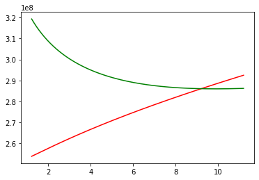

```python
import matplotlib.pyplot as plt
plt.plot(w,tr,c="red")
plt.plot(w,ts,c="green")
```

```python
    rr = Ridge(alpha=9.2)
    model = rr.fit(xtrain,ytrain)
    tr_pred = model.predict(xtrain)
    ts_pred = model.predict(xtest)
    tr_err = round(mean_squared_error(ytrain,tr_pred),2)
    ts_err = round(mean_squared_error(ytest,ts_pred),2)
    tr.append(tr_err)
    ts.append(ts_err)
```

```python
tr_err
```

```
286019481.79
```

```python
ts_err
```

```
286024588.65
```

lamba value is reliable for only one sample of the model (RS_31),if we change the sample reliability of model will affect,so to overcome this,we will do cross validation technique

# GridsearchCV

```python
q = 0.1
w = []
for i in range(0,1000):
    w.append(q)
    q = q + 0.01
```

```python
from sklearn.model_selection import GridSearchCV
rr = Ridge(alpha=w)
tuning_grid = {"alpha":w}
cv = GridSearchCV(rr,tuning_grid,scoring="neg_mean_squared_error",cv=10)
cvmodel = cv.fit(Xnew,Y)
cvmodel.best_params_
```

```
{'alpha': 2.5199999999999902}
```

```python
rr = Ridge(alpha=2.5199999999999902)
model = rr.fit(Xnew,Y)
tr_pred = model.predict(xtrain)
ts_pred = model.predict(xtest)
tr_err = round(mean_squared_error(ytrain,tr_pred),2)
ts_err = round(mean_squared_error(ytest,ts_pred),2)
print(tr_err,ts_err)
```

```
269768736.86 234901426.48
```

# Make test set ready for prediction

```python
xtrain.columns
```

```
Index(['LotArea', 'YearBuilt', 'YearRemodAdd', 'BsmtUnfSF', 'TotalBsmtSF',
       'GrLivArea', 'BsmtFullBath', 'TotRmsAbvGrd', 'Fireplaces', 'GarageCars',
       ...
       'SaleCondition_Alloca', 'SaleCondition_Family', 'SaleCondition_Normal',
       'SaleCondition_Partial', 'ExterQual_Ex', 'Exterior2nd_Other',
       'MSZoning_RM', 'Neighborhood_ClearCr', 'RoofMatl_Metal',
       'PavedDrive_N'],
      dtype='object', length=136)
```

```python
cols_to_keep = xtrain.columns
```

```python
test.Alley=test.Alley.fillna("NoAlleyAccess")
test.BsmtQual=test.BsmtQual.fillna("NoBasement")
test.BsmtCond=test.BsmtCond.fillna("NoBasement")
test.BsmtExposure=test.BsmtExposure.fillna("NoBasement")
test.BsmtFinType1=test.BsmtFinType1.fillna("NoBasement")
test.BsmtFinType2=test.BsmtFinType2.fillna("NoBasement")
test.FireplaceQu=test.FireplaceQu.fillna("NoFireplace")
test.GarageType =test.GarageType.fillna("NoGarage")
test.GarageFinish =test.GarageFinish.fillna("NoGarage")
test.GarageQual = test.GarageQual.fillna("No Garage")
test.GarageCond =test.GarageCond.fillna("NoGarage")
test.PoolQC =test.PoolQC.fillna("NoPool")
test.Fence =test.Fence.fillna("NoFence")
test.MiscFeature = test.MiscFeature.fillna("None")
```

```python
test.MSSubClass.replace({20:"1-STORY 1946 & NEWER ALL STYLES",
                     30:"1-STORY 1945 & OLDER",
                     40:"1-STORY W/FINISHED ATTIC ALL AGES",
                     45:"1-1/2 STORY - UNFINISHED ALL AGES",
                     50:"1-1/2 STORY FINISHED ALL AGES",
                     60:"2-STORY 1946 & NEWER",
                     70:"2-STORY 1945 & OLDER",
                     75:"2-1/2 STORY ALL AGES",
                     80 : "SPLIT OR MULTI-LEVEL",
                     85 : "SPLIT FOYER",
                     90 : "DUPLEX - ALL STYLES AND AGES",
                     120 : "1-STORY PUD (Planned Unit Development) - 1946 & NEWER",
                     150 : "1-1/2 STORY PUD - ALL AGES",
                     160 : "2-STORY PUD - 1946 & NEWER",
                     180 : "PUD - MULTILEVEL - INCL SPLIT LEV/FOYER",
                     190 : "2 FAMILY CONVERSION - ALL STYLES AND AGES"}, inplace=True)
```

```python
test.OverallQual.replace({10 : "Very Excellent",
                       9 : "Excellent",
                       8 : "Very Good",
                       7 : "Good",
                       6 : "Above Average",
                       5 : "Average",
                       4 : "Below Average",
                       3 : "Fair",
                       2 : "Poor",
                       1 : "Very Poor"}, inplace=True)
```

```python
test.OverallCond.replace({10 : "Very Excellent",
                       9 : "Excellent",
                       8 : "Very Good",
                       7 : "Good",
                       6 : "Above Average",
                       5 : "Average",
                       4 : "Below Average",
                       3 : "Fair",
                       2 : "Poor",
                       1 : "Very Poor"}, inplace=True)
```

remove corr & anova cols

```python
testb = test.drop(labels=["Id","Street","Utilities","LandSlope","KitchenAbvGr","BsmtHalfBath","BsmtFinSF2","3SsnPorch","MoSold","PoolArea","ScreenPorch","BedroomAbvGr"],axis=1)
```

```python
testb.shape
```

```
(1459, 68)
```

```python
catb = []
conb = []
for i in testb.columns:
    if(testb[i].dtypes == "object"):
        catb.append(i)
        x = testb[i].mode()[0]
        testb[i] = testb[i].fillna(x)
    else:
        conb.append(i)
        x = round(testb[i].mean(),2)
        testb[i] = testb[i].fillna(x)
```

```python
#catb
```

```python
#conb
```

```python
testb[conb].columns
```

```
Index(['LotFrontage', 'LotArea', 'YearBuilt', 'YearRemodAdd', 'MasVnrArea',
       'BsmtFinSF1', 'BsmtUnfSF', 'TotalBsmtSF', '1stFlrSF', '2ndFlrSF',
       'LowQualFinSF', 'GrLivArea', 'BsmtFullBath', 'FullBath', 'HalfBath',
       'TotRmsAbvGrd', 'Fireplaces', 'GarageYrBlt', 'GarageCars', 'GarageArea',
       'WoodDeckSF', 'OpenPorchSF', 'EnclosedPorch', 'MiscVal', 'YrSold'],
      dtype='object')
```

```python
test1 = testb[['LotFrontage', 'LotArea', 'YearBuilt', 'YearRemodAdd', 'MasVnrArea',
       'BsmtFinSF1', 'BsmtUnfSF', 'TotalBsmtSF', '1stFlrSF', '2ndFlrSF',
       'LowQualFinSF', 'GrLivArea', 'BsmtFullBath', 'FullBath', 'HalfBath',
       'TotRmsAbvGrd', 'Fireplaces', 'GarageYrBlt', 'GarageCars', 'GarageArea',
       'WoodDeckSF', 'OpenPorchSF', 'EnclosedPorch', 'MiscVal', 'YrSold']]
```

```python
pd.DataFrame(ss.transform(test1),columns=test1.columns)
XT1 = pd.DataFrame(ss.transform(test1),columns=test1.columns)
XT1.shape
```

```
(1459, 25)
```

```python
#pd.set_option('display.max_columns',None)
#XT2
```

```python
XT2 = pd.get_dummies(testb[catb])
XT2.shape
```

```
(1459, 277)
```

```python
Xtest_new = XT1.join(XT2)
#Xtest_new
```

```python
e = ['RoofMatl_Metal','GarageQual_Ex','Exterior2nd_Other']
```

```python
for i in e:
    Xtest_new[i]=0
```

```python
Xtest_final=Xtest_new[cols_to_keep]
Xnew.shape
```

```
(1243, 136)
```

```python
Xtest_final.shape
```

```
(1459, 136)
```

```python
pred=model.predict(Xtest_final)
pred
```

```
array([[110296.39713279],
       [162352.06022805],
       [196462.64936386],
       ...,
       [177546.81374953],
       [119146.55931873],
       [215762.5839729 ]])
```

```python
T = test[["Id"]]
```

```python
T['SalePrice']=pred
```

```python
T.head(5)
```

|  | Id | SalePrice |
| --- | --- | --- |
| 0 | 1461 | 110296.397133 |
| 1 | 1462 | 162352.060228 |
| 2 | 1463 | 196462.649364 |
| 3 | 1464 | 202289.968695 |
| 4 | 1465 | 197342.965976 |

```python
T.to_csv("Desktop/Project_Housing_submission.csv")
```